# Activity Prediction Report

Rohit Benny Abraham

8/12/2020

## Overview

The goal of your project is to predict the manner in which they did the exercise. This is the “classe” variable in the training set.

In order to achieve this objective, data cleaning (for NA values) and feature selection was performed prior to applying random forest and generalized boosted regression model (GBM) as our prediction models.

## Loading dependencies and data

```r
library(caret)
```

```r
library(ggplot2)
library(randomForest)
library(gbm)
library(corrplot)
```

## Data description

The training dataset consists of 160 different attributes with over 19000 observations. Six young healthy participants were asked to perform one set of 10 repetitions of the Unilateral Dumbbell Biceps Curl in five different fashions, which is recorded in our target variable (classe). Below is the class description:

- Exactly according to the specification (Class A)
- Throwing the elbows to the front (Class B)
- Lifting the dumbbell only halfway (Class C)
- Lowering the dumbbell only halfway (Class D)
- Throwing the hips to the front (Class E)

## Data Preprocessing

Then removed all the redundant variables by checking for non-zero variance and highly correlated variables (with a cut-off 0.8). After these steps, we are left with 40 variables for predictions.

```
           Feature selection process
```

| Process | Dataset | Total Features |
| --- | --- | --- |
| Initial | train/test | 160/160 |
| NA treatment | train/test | 86/53 |
| Non- Zero variance | train/test | 53/53 |
| Correlation check | train/test | 40/40 |

## Model Building

Two methods were attempted, Random forest (RF) and Generalized Boosted Regression Model (GBM) out of which the RF model was the better performing model with an accuracy of ~99%. In both the models, cross-validation was passed as a control parameter to generalized the data and to remove the bias, if any.

### 1. Random forest

```
##
## Call:
##  randomForest(x = x, y = y, mtry = param$mtry)
##                Type of random forest: classification
##                      Number of trees: 500
## No. of variables tried at each split: 20
##
##         OOB estimate of  error rate: 0.87%
## Confusion matrix:
##      A    B    C    D    E  class.error
## A 3903    2    0    0    1 0.0007680492
## B   20 2627   10    0    1 0.0116629044
## C    0   21 2358   17    0 0.0158597663
## D    2    0   34 2213    3 0.0173179396
## E    0    0    2    7 2516 0.0035643564
```

```
## Confusion Matrix and Statistics
##
##           Reference
## Prediction    A    B    C    D    E
##          A 1669    7    0    0    0
##          B    4 1123   12    0    0
##          C    1    9 1010   16    4
##          D    0    0    4  947    4
##          E    0    0    0    1 1074
##
## Overall Statistics
##
##                Accuracy : 0.9895
##                  95% CI : (0.9865, 0.9919)
##     No Information Rate : 0.2845
##     P-Value [Acc > NIR] : < 2.2e-16
##
##                   Kappa : 0.9867
##
##  Mcnemar's Test P-Value : NA
##
## Statistics by Class:
##
##                      Class: A Class: B Class: C Class: D Class: E
## Sensitivity            0.9970   0.9860   0.9844   0.9824   0.9926
## Specificity            0.9983   0.9966   0.9938   0.9984   0.9998
## Pos Pred Value         0.9958   0.9860   0.9712   0.9916   0.9991
## Neg Pred Value         0.9988   0.9966   0.9967   0.9966   0.9983
## Prevalence             0.2845   0.1935   0.1743   0.1638   0.1839
## Detection Rate         0.2836   0.1908   0.1716   0.1609   0.1825
## Detection Prevalence   0.2848   0.1935   0.1767   0.1623   0.1827
## Balanced Accuracy      0.9977   0.9913   0.9891   0.9904   0.9962
```

The accuracy of the RF model is quite high i.e ~99% with out of sample error being 0.011

### 2. Generalized Boosted Regression Model

```
## A gradient boosted model with multinomial loss function.
## 150 iterations were performed.
## There were 39 predictors of which 39 had non-zero influence.
```

```
## Confusion Matrix and Statistics
##
##           Reference
## Prediction    A    B    C    D    E
##          A 1647   26    0    0    3
##          B   19 1053   49    1   12
##          C    4   49  966   51   14
##          D    2    7    9  898   17
##          E    2    4    2   14 1036
##
## Overall Statistics
##
##                Accuracy : 0.9516
##                  95% CI : (0.9458, 0.9569)
##     No Information Rate : 0.2845
##     P-Value [Acc > NIR] : < 2.2e-16
##
##                   Kappa : 0.9387
##
##  Mcnemar's Test P-Value : 3.95e-08
##
## Statistics by Class:
##
##                      Class: A Class: B Class: C Class: D Class: E
## Sensitivity            0.9839   0.9245   0.9415   0.9315   0.9575
## Specificity            0.9931   0.9829   0.9757   0.9929   0.9954
## Pos Pred Value         0.9827   0.9286   0.8911   0.9625   0.9792
## Neg Pred Value         0.9936   0.9819   0.9875   0.9867   0.9905
## Prevalence             0.2845   0.1935   0.1743   0.1638   0.1839
## Detection Rate         0.2799   0.1789   0.1641   0.1526   0.1760
## Detection Prevalence   0.2848   0.1927   0.1842   0.1585   0.1798
## Balanced Accuracy      0.9885   0.9537   0.9586   0.9622   0.9765
```

The accuracy of the GBM model is also high i.e ~95% with out of sample error being 0.05

## Results

Here, we apply the best model (RF) because of its high accuracy and low out of sample error rate, to the test set to predict the activity type for each of the 20 observations.

```
##  [1] B A B A A E D B A A B C B A E E A B B B
## Levels: A B C D E
```

## Correlation plot

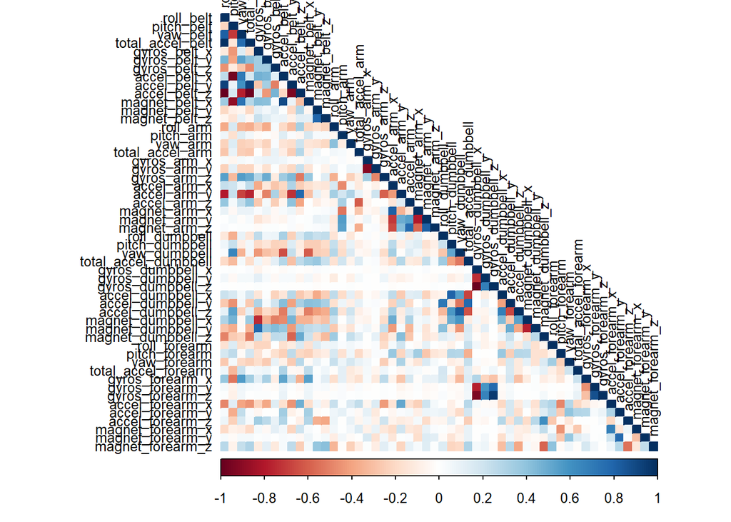

## Accuracy plot for Random Forest model (with cross validation)

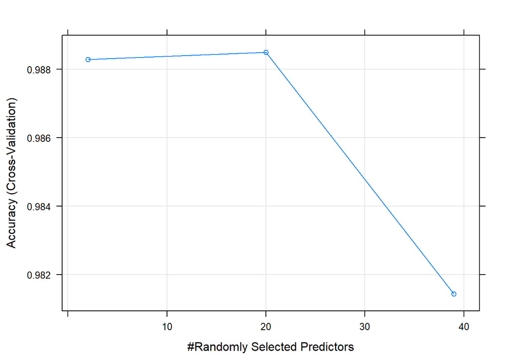

## Accuracy plot for GBM (with cross validation)

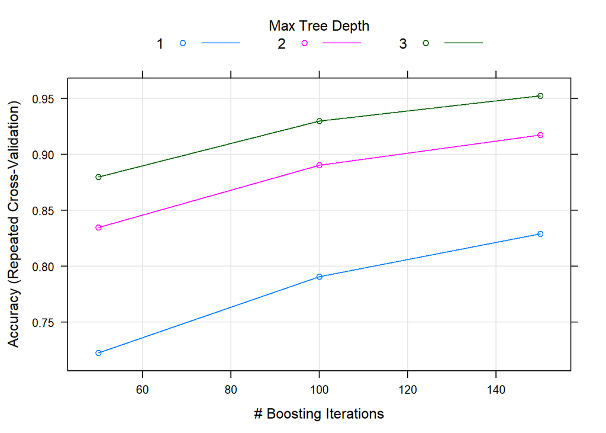